# Practical Lab 5 - Multivariate Regression, Non-Parametric Models and Cross-Validation

## Diabetes Progression Prediction

We are going to use a person’s Body Mass Index (BMI) to predict how their diabetes might progress. To do this, we’ll use something called polynomial regression models.

But we can’t just assume our models are perfect. So, we’ll use three different tools to check how well they’re doing: R-squared, Mean Absolute Percentage Error (MAPE), and Mean Absolute Error (MAE). These tools will help us understand if our predictions are on the right track

### Step 1: Data Loading, Preparation and EDA

First, we need to gather our tools and data. We’ll load the necessary libraries that will help us in our analysis. Then, we’ll bring in the diabetes dataset. But here’s the catch - we’re only going to use the BMI feature for our analysis. It’s like focusing our microscope on just one aspect of the data.

```
        age       sex       bmi        bp        s1        s2        s3  \
0  0.038076  0.050680  0.061696  0.021872 -0.044223 -0.034821 -0.043401
1 -0.001882 -0.044642 -0.051474 -0.026328 -0.008449 -0.019163  0.074412
2  0.085299  0.050680  0.044451 -0.005670 -0.045599 -0.034194 -0.032356
3 -0.089063 -0.044642 -0.011595 -0.036656  0.012191  0.024991 -0.036038
4  0.005383 -0.044642 -0.036385  0.021872  0.003935  0.015596  0.008142

         s4        s5        s6  target
0 -0.002592  0.019907 -0.017646   151.0
1 -0.039493 -0.068332 -0.092204    75.0
2 -0.002592  0.002861 -0.025930   141.0
3  0.034309  0.022688 -0.009362   206.0
4 -0.002592 -0.031988 -0.046641   135.0
```

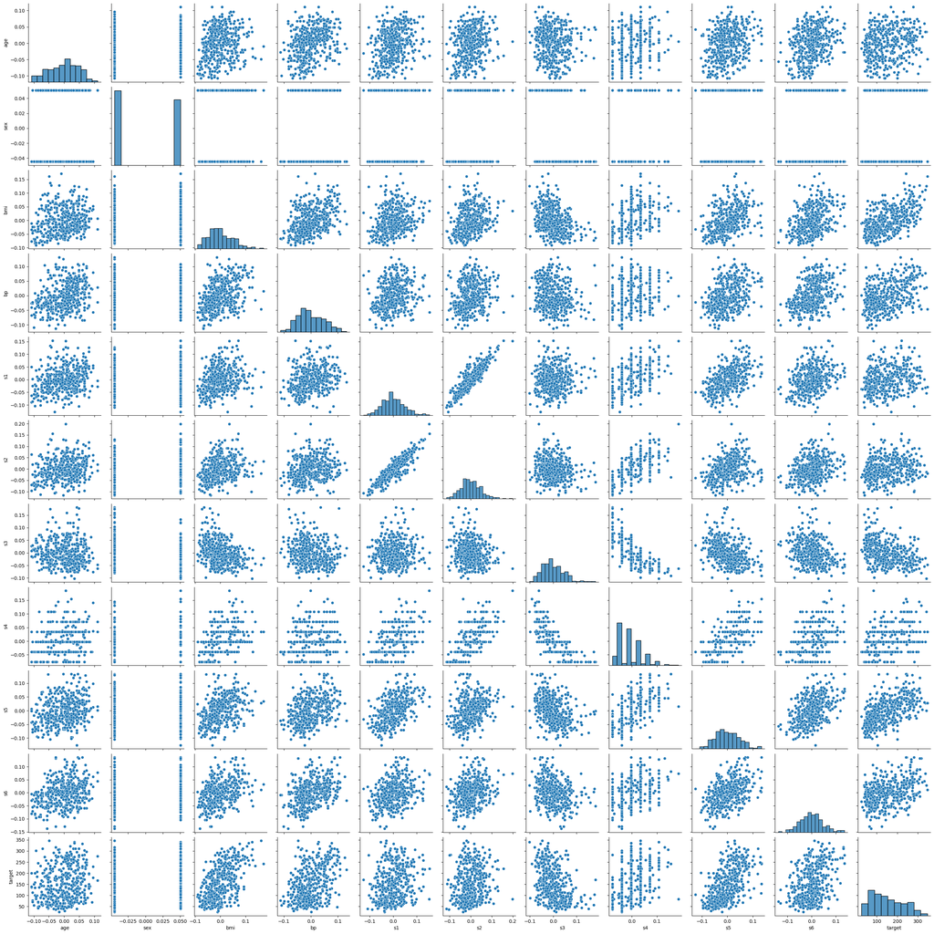

```python
# Imported libraries and modules
import numpy as np
import pandas as pd
import matplotlib.pyplot as plt
from sklearn.preprocessing import PolynomialFeatures
from sklearn.linear_model import LinearRegression
from sklearn.metrics import mean_absolute_error, r2_score
from sklearn import datasets
from sklearn.model_selection import train_test_split
import seaborn as sns
from sklearn.tree import DecisionTreeRegressor
from sklearn.neighbors import KNeighborsRegressor
from sklearn.pipeline import make_pipeline
from sklearn.model_selection import cross_validate
from sklearn.model_selection import train_test_split
from sklearn.metrics import make_scorer

diabetes = datasets.load_diabetes()
X = diabetes.data[:, np.newaxis, 2]
y = diabetes.target

# Convert to DataFrame for easier manipulation
df = pd.DataFrame(diabetes.data, columns=diabetes.feature_names)
df['target'] = diabetes.target

# Display the first few rows of the DataFrame
print(df.head())

# Perform EDA
sns.pairplot(df)
```

The graph above is a scatterplot Matrix. Think of this scatterplot matrix as a grand music festival! Each tiny plot is like a different stage where two bands (or in our case, data features) are jamming together.

When the dots form a line, it’s like the two bands are playing in perfect harmony - their music (or data points) are in sync. But when the dots are scattered all over, it’s like a wild jam session - there’s no clear rhythm or pattern to their music.

Now, we’re like music critics focusing on the BMI band today. We’re looking for stages where BMI is jamming with other health indicators. This will help us understand if higher BMI is playing a duet with higher blood pressure or any other health metric.

### Step 2: Data Splitting and Data Validation

Next up, we’re going to divide our data into three parts: training, validation, and test sets. Why do we do this? Well, it’s like a dress rehearsal for our models. They learn from the training set, tune their performance with the validation set, and finally, they give their big performance on the test set - which is completely unseen data! This way, we can evaluate how well our models can predict diabetes progression on new data.

```python
# Set the proportion of data to be used for testing
test_ratio = 0.15

# Spliting the data into training+validation set and testing set
# The test_size parameter determines the proportion of the original data is used for the test set.
# random_state parameter is used for initializing the internal random number generator, which will decide the splitting of data into train and test indices.
X_train_val, X_test, y_train_val, y_test = train_test_split(X, y, test_size=test_ratio, random_state=0)

# Printing the sizes of the training+validation set and testing set
print("Training+Validation set has", X_train_val.shape[0], "samples")
print("Testing set has", X_test.shape[0], "samples")

# Set the proportion of training+validation data to be used for validation
validation_ratio = 0.1765

# Split the training+validation set into training set and validation set
# The test_size parameter determines the proportion of the training+validation data is used for the validation set.
X_train, X_val, y_train, y_val = train_test_split(X_train_val, y_train_val, test_size=validation_ratio, random_state=0)

# Print the sizes of the training set and validation set
print("Training set has", X_train.shape[0], "samples")
print("Validation set has", X_val.shape[0], "samples")

models = {
    'poly1': make_pipeline(PolynomialFeatures(1), LinearRegression()),
    'poly2': make_pipeline(PolynomialFeatures(2), LinearRegression()),
    'tree3': DecisionTreeRegressor(max_depth=3),
    'tree5': DecisionTreeRegressor(max_depth=5),
    'knn3': KNeighborsRegressor(n_neighbors=3),
    'knn5': KNeighborsRegressor(n_neighbors=5),
}

# Define MAPE
def mape(y_true, y_pred):
    return np.mean(np.abs((y_true - y_pred) / y_true)) * 100

# Make it a scorer
mape_scorer = make_scorer(mape, greater_is_better=False)

# Define MAE scorer
mae_scorer = make_scorer(mean_absolute_error, greater_is_better=False)

# Initialize a DataFrame to store the results
results = pd.DataFrame(columns=['Model', 'R2 Mean', 'R2 Std', 'MAE Mean', 'MAE Std', 'MAPE Mean', 'MAPE Std'], dtype=float)

# Model column should be of object type
results['Model'] = results['Model'].astype(object)

# Perform cross-validation and store the results
for name, model in models.items():
    scores = cross_validate(model, X_train, y_train, cv=5, scoring={'r2': 'r2', 'neg_mean_absolute_error': mae_scorer, 'MAPE': mape_scorer})
    results.loc[len(results)] = {
        'Model': name,
        'R2 Mean': scores['test_r2'].mean(),
        'R2 Std': scores['test_r2'].std(),
        'MAE Mean': -scores['test_neg_mean_absolute_error'].mean(),
        'MAE Std': scores['test_neg_mean_absolute_error'].std(),
        'MAPE Mean': -scores['test_MAPE'].mean(),
        'MAPE Std': scores['test_MAPE'].std(),
    }

# Print the results
print(results)
```

```
Training+Validation set has 375 samples
Testing set has 67 samples
Training set has 308 samples
Validation set has 67 samples
   Model   R2 Mean    R2 Std   MAE Mean   MAE Std  MAPE Mean  MAPE Std
0  poly1  0.332995  0.116207  51.422619  2.805461  47.136286  8.716395
1  poly2  0.327197  0.119524  51.696765  2.872992  47.282442  8.692464
2  tree3  0.227621  0.130416  54.320277  1.096447  48.517542  7.717720
3  tree5  0.139303  0.114351  56.187982  1.580844  51.160248  8.116428
4   knn3  0.133669  0.087398  57.795576  2.347165  52.475755  6.066532
5   knn5  0.211445  0.091062  55.857081  1.370656  49.546515  6.942194
```

### Step 3: Model Training and Evaluation

Think of R-squared (R2), Mean Absolute Error (MAE), and Mean Absolute Percentage Error (MAPE) as different ways to grade a model’s performance, like report cards for your model.

```
R2 is like the model’s score in a multiple-choice test. It tells you how much of the test (or your data) the model got right. A high R2 means the model understood a lot about your data.

MAE is like measuring how far off the model’s answers were in a fill-in-the-blank test. It tells you, on average, how much the model’s predictions missed the actual values.

MAPE is similar to MAE, but it’s like grading on a curve. It tells you the error as a percentage, which can be handy when you want to compare models that are predicting different things.
```

Just like in school, you might want to look at all these grades to understand how well your model is doing. A model might ace one test (have a high R2), but flunk another (have a high MAE). So, considering multiple metrics gives you a more complete picture of your model’s performance.

Let’s think of this as a talent show where different models are contestants. They’re all showing off their skills, trying to impress us with their ability to predict outcomes based on the data we feed them.

The R2 Mean is like the score given by the judges. It tells us how well each model is doing. The higher the R2 Mean, the better the model is at making accurate predictions.

So, when we say we’re looking for the model with the highest R2 Mean, we’re essentially looking for the superstar of the show, the one that outshines all others with its predictive prowess.

```python
# Identify the best model (the one with the highest R2 Mean)
best_model_name = results.loc[results['R2 Mean'].idxmax(), 'Model']
best_model = models[best_model_name]
print(f"R2 Mean of best model: {results['R2 Mean'].max()}")
```

```
R2 Mean of best model: 0.3329945771326345
```

### Step 4: Model Selection

Based on the validation R2, we’ll pick the star of our show, the best model! This chosen model will then take the spotlight for our final evaluation. It’s like choosing the best performer for the grand finale

```python
best_model.fit(X_train, y_train)
y_pred = best_model.predict(X_test)
print(f'Best model: {best_model_name}')
print(f"  Test R2: {r2_score(y_test, y_pred):.2f}")
print(f"  Test MAE: {mean_absolute_error(y_test, y_pred):.2f}")
print(f"  Test MAPE: {mape(y_test, y_pred):.2f}")
```

```
Best model: poly1
  Test R2: 0.16
  Test MAE: 51.57
  Test MAPE: 42.54
```

### Step 5: Visualizing the Model

Let’s bring our data and model to life by plotting them. We’ll plot the data points and our best model fit. It’s like painting a picture with our data and model. This will help us visualize how well our model is doing.

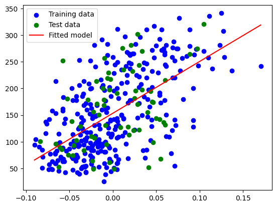

```python
# Fit the model on the training data
best_model.fit(X_train, y_train)

# Make predictions on the test data
y_pred = best_model.predict(X_test)

# Plot the training data points
plt.scatter(X_train, y_train, color='blue', label='Training data')

# Plot the test data points
plt.scatter(X_test, y_test, color='green', label='Test data')

# Plot the fitted model
x_line = np.linspace(X_train.min(), X_train.max(), 100).reshape(-1, 1)
y_line = best_model.predict(x_line)
plt.plot(x_line, y_line, color='red', label='Fitted model')

# Add a legend
plt.legend()

# Show the plot
```

### Step 6: Model Interpretation

Finally, we’re going to decode our chosen model. We’ll jot down its equation, just like a secret formula. Then, we’ll use this formula to calculate the expected diabetes progression for a specific BMI value. It’s like using a secret key to predict the future

```python
# Fit the model on the training data
model = LinearRegression()
model.fit(X_train, y_train)

# Print the equation of the model
print(f"Diabetes progression = {model.intercept_} + {model.coef_[0]} * BMI")

# Use the model to predict the diabetes progression for a specific BMI value
bmi_value = 25
predicted_progression = model.predict([[bmi_value]])
print(f"The expected diabetes progression for a BMI value of {bmi_value} is {predicted_progression[0]}")
```

```
Diabetes progression = 153.31612207210253 + 971.3795677966237 * BMI
The expected diabetes progression for a BMI value of 25 is 24437.805316987695
```

# Conclusion

This is a simple linear equation that predicts diabetes progression based on BMI (Body Mass Index).

```
153.31612207210253 is the starting point or the ‘base’ diabetes progression when BMI is zero. It’s like the base fare of a taxi ride before you’ve even traveled any distance.

971.3795677966237 is the rate at which diabetes progression increases for each unit increase in BMI. It’s like the rate at which the taxi fare increases for each kilometer you travel.
```

So, if you plug in a BMI value of 25 into this equation, you get an expected diabetes progression of 24437.805316987695. This means that for a person with a BMI of 25, the model predicts their diabetes to progress to this value.

In this notebook, we’ve embarked on a full-fledged machine learning journey to predict diabetes progression using BMI. Our journey began with loading and dividing the data, followed by training and validating Multivariate Regression Using Polynomial regression models of varying complexities.

We then picked the best model, our champion, based on its performance on the validation set using the R2. This champion model was then put to the ultimate test on the test set, and we visualized its predictions.

In the end, we decoded the model by noting down its equation and used it to calculate the expected diabetes progression for a specific BMI value.

```python
# Calculate the mean absolute error (MAE) for the test data
y_test_pred = best_model.predict(X_test)

test_mae = mean_absolute_error(y_test, y_test_pred)

# Calculate the R2 score for the test data
test_r2 = r2_score(y_test, y_test_pred)

# Calculate the mean absolute percentage error (MAPE) for the test data
test_mape = np.mean(np.abs((y_test - y_test_pred) / y_test)) * 100

# Define the equation of the best model and the expected progression
equation = f"Diabetes progression = {model.intercept_} + {model.coef_[0]} * BMI"
bmi_value = 25
expected_progression = model.predict([[bmi_value]])

# Print the R2 score, MAE, MAPE, and best model equation for the test data
print(f'Test R2: {test_r2}')
print(f'Test MAE: {test_mae}')
print(f'Test MAPE: {test_mape}%')
print(f'Best model equation: {equation}')
print(f'Expected diabetes progression for a BMI value of {bmi_value}: {expected_progression[0]}')
```

```
Test R2: 0.16079911322770868
Test MAE: 51.57367407926355
Test MAPE: 42.5438439540544%
Best model equation: Diabetes progression = 153.31612207210253 + 971.3795677966237 * BMI
Expected diabetes progression for a BMI value of 25: 24437.805316987695
```